# Max size clustering

#### Loading and assessing data

This demonstration is based on the scenario that an event is taking part in Amsterdam, and visitors are to be allocated to bus seats to be taken to the event.

First, we load a sample CSV file for the visitors to a particular event, and see whether that data looks as we expect.

```r
data <- na.omit(read.csv("visitor_locations.csv"))
head(data)
```

```
##        lat      lon number
## 1 50.76807 5.705593      4
## 2 50.76883 6.010053      3
## 3 50.77212 6.021169      3
## 4 50.77350 5.707813      2
## 5 50.77480 6.009212      2
## 6 50.77504 5.712374      2
```

```r
summary(data)
```

```
##       lat             lon            number
##  Min.   :50.77   Min.   :3.401   Min.   :  1.000
##  1st Qu.:52.07   1st Qu.:4.751   1st Qu.:  1.000
##  Median :52.30   Median :4.920   Median :  2.000
##  Mean   :52.22   Mean   :5.045   Mean   :  2.028
##  3rd Qu.:52.38   3rd Qu.:5.255   3rd Qu.:  2.000
##  Max.   :53.45   Max.   :7.193   Max.   :193.000
```

*Note*: The data is structured such that there are multiple longitudes / latitudes with multiple people, so we should duplicate those rows so seats are appropriately allocated.

```r
data <- data[rep(row.names(data), data$number), 1:2]
names(data) <- c("lat", "lon")
```

#### National visitor distribution

We plot where the visitors come from.

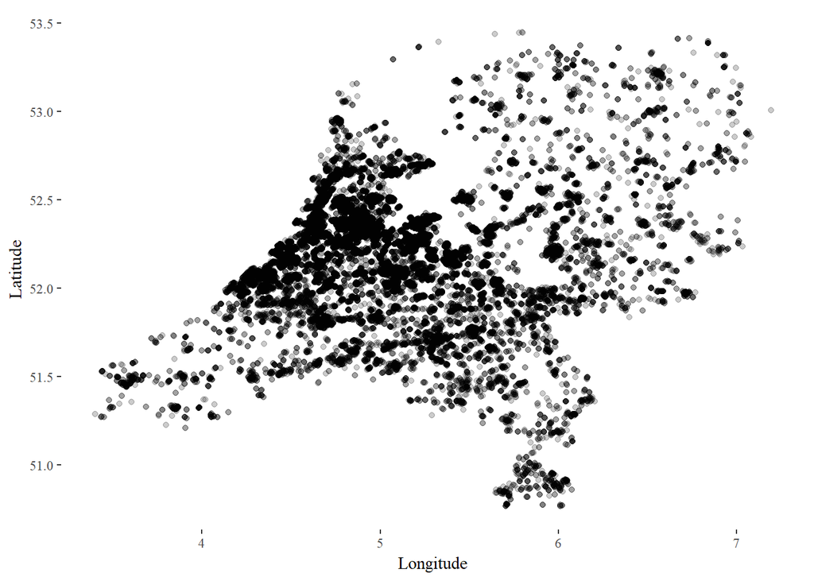

```r
ggplot(data = data, aes(lon, lat))+
  geom_point(alpha = 0.2)+
  theme_tufte()+
  labs(x ="Longitude", y = "Latitude")+
  ggsave("fulldata.png")
```

*Note*: We see there are many visitors from near Amsterdam, who are unlikely to want to make use of the bus transport there.

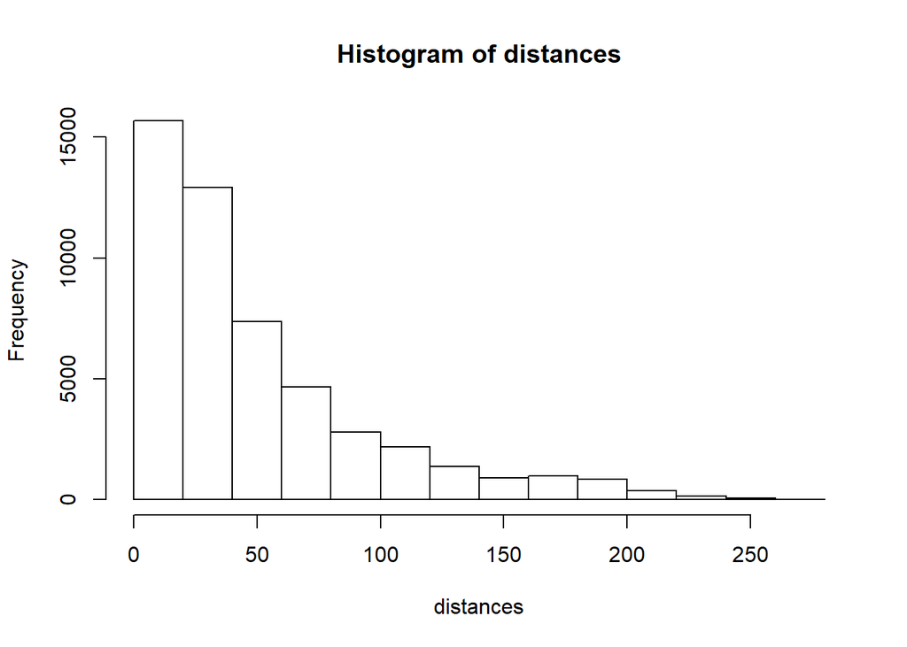

```r
# Lat & Lon of central Amsterdam location: 52.314762, 4.941845

library(geosphere)
distances <- distHaversine(data, c(52.314762, 4.941845), r=6378137) / 1000
hist(distances)
```

```r
# This histogram looks as expected: most visitors come from closer to the Amsterdam than from further away!
```

As a rule of thumb, we remove all visitors that live within a 35km radius of central Amsterdam.

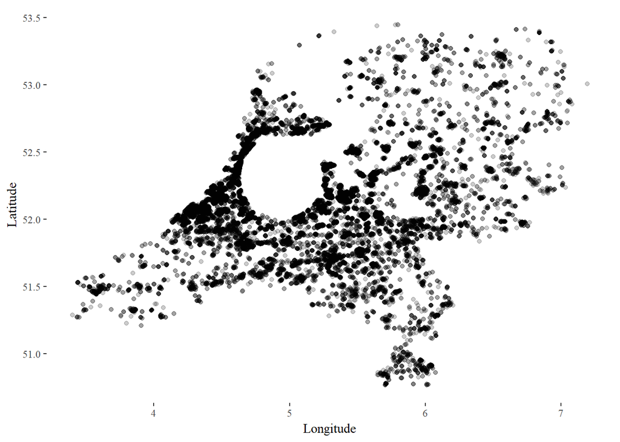

```r
data_w_dist <- cbind(data, distances)

# Remove everyone less than 35km away
data_filtered <- data_w_dist %>%
  filter(distances > 35)
ggplot(data = data_filtered, aes(lon, lat))+
  geom_point(alpha = 0.2)+
  theme_tufte()+
  labs(x ="Longitude", y = "Latitude")+
  ggsave("Amsterdamremoved.png")
```

### Clustering algorithm

We use repeated hierarchical clustering. This algorithm creates a dendrogram, combining those datapoints that are closest together one at a time. Therefore, one may cut this tree at any height to create a set number of clusters.

For the clustering, we use a random sample of 20% of the data: this is not only an estimate of likely demand for this service, but also cuts down on running time of the algorithm itself.

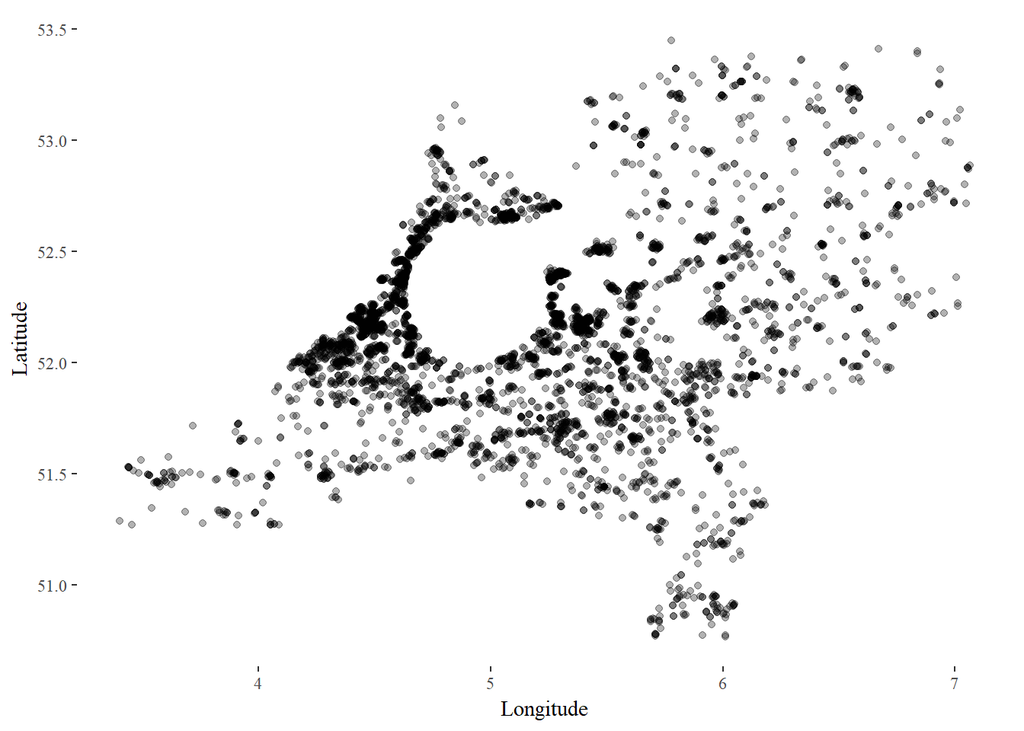

```r
set.seed(9876)
reduced <- data_filtered[ sample(1:nrow(data_filtered), nrow(data_filtered)/5 ) , 1:2]

ggplot(data = reduced, aes(lon, lat))+
  geom_point(alpha = 0.3)+
  theme_tufte()+
  labs(x ="Longitude", y = "Latitude")+
  ggsave("datareduced.png")
```

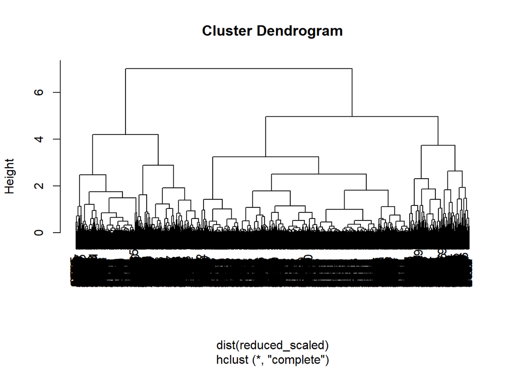

```r
# Normalise factors
meanreduced_lat <- mean(reduced$lat)
meanreduced_lon <- mean(reduced$lon)
sdreduced_lat <- sd(reduced$lat)
sdreduced_lon <- sd(reduced$lon)
reduced_scaled <- data.frame(
                  cbind(lat = ((reduced$lat - meanreduced_lat) / sdreduced_lat),
                        lon = ((reduced$lon - meanreduced_lon) / sdreduced_lon)))

clusters <- hclust(dist(reduced_scaled))
plot(clusters)
```

We create repeated hierarchical clusterings, cut at different heights, to arrive at a dendrogram where the maximum cluster size is 59 (the number of seats per bus). The clusters with a reasonable number of visitors in it are saved, and the clustering algorithm is run again on the remaining visitors. This is repeated until all visitors are allocated a bus.

```r
start_time <- Sys.time()
maxsize <- 1000
i <- 2
loopnum <- 1
redo_clusters <- reduced_scaled
dat_size <- nrow(redo_clusters)
saved_clusters <- data.frame(lat = as.numeric(),
                             lon = as.numeric(),
                             labels = as.integer(),
                             loopnum = as.integer())

while(dat_size > 0){
  treemodel <- hclust(dist(redo_clusters))
  repeat{
    clusterlabels <- cutree(treemodel, i)
    clustersizes <- cbind(redo_clusters, labels = clusterlabels, loopn = rep(loopnum, nrow(redo_clusters)))
    clustersums <- clustersizes %>% group_by(labels) %>% summarise(size = n())
    maxsize <- max(clustersums$size)
    thirdlargestsize <- ifelse(is.na(nth(clustersums$size, 3)), 0, 30)
    accurate_clusters <- (clustersizes %>% group_by(labels) %>% summarise(size = n()) %>% filter(size >= thirdlargestsize) %>% select(labels))[[1]]
    if(maxsize <= 59){
      break
    }
    i = i + 1
  }
saved_clusters <- rbind(saved_clusters, (clustersizes %>% filter(labels %in% accurate_clusters)))
redo_clusters <- clustersizes %>% filter(!(labels %in% accurate_clusters))
redo_clusters <- redo_clusters[,1:2]
dat_size <- nrow(redo_clusters)
print(paste("Number of clusters in this round: ", i))
print(paste("Round ", loopnum, " is over"))
i <- 2
loopnum <- loopnum + 1
}
```

```
## [1] "Number of clusters in this round:  762"
## [1] "Round  1  is over"
## [1] "Number of clusters in this round:  638"
## [1] "Round  2  is over"
## [1] "Number of clusters in this round:  385"
## [1] "Round  3  is over"
## [1] "Number of clusters in this round:  193"
## [1] "Round  4  is over"
## [1] "Number of clusters in this round:  93"
## [1] "Round  5  is over"
## [1] "Number of clusters in this round:  57"
## [1] "Round  6  is over"
## [1] "Number of clusters in this round:  25"
## [1] "Round  7  is over"
## [1] "Number of clusters in this round:  3"
## [1] "Round  8  is over"
```

```r
running_time <- Sys.time() - start_time
print(paste("Total running time was: ", running_time))
```

```
## [1] "Total running time was:  31.7987189292908"
```

#### Results

We first see how many people were allocated per bus, and how many buses are needed for this particular event.

```r
# Only reassign saved_clusters_plot when algorithm has run successfully!
saved_clusters_plot <- saved_clusters %>%
  mutate(lat = lat * sdreduced_lat + meanreduced_lat,
         lon = lon * sdreduced_lon + meanreduced_lon)
saved_clusters_plot$clustnum <- paste(as.character(saved_clusters_plot$labels), "-", as.character(saved_clusters_plot$loopn))

# Calculate how many people per bus, and how many buses are needed
saved_clusters_plot %>%
  group_by(clustnum) %>%
  summarise(count = n())
```

```
## # A tibble: 126 x 2
##    clustnum count
##    <chr>    <int>
##  1 1 - 4       33
##  2 1 - 5       46
##  3 1 - 8       35
##  4 10 - 7      49
##  5 104 - 4     36
##  6 11 - 5      47
##  7 11 - 7      36
##  8 113 - 4     42
##  9 114 - 3     35
## 10 116 - 2     32
## # ... with 116 more rows
```

```r
length(unique(saved_clusters_plot$clustnum))
```

```
## [1] 126
```

We can plot the groups of visitors, distributed across the country.

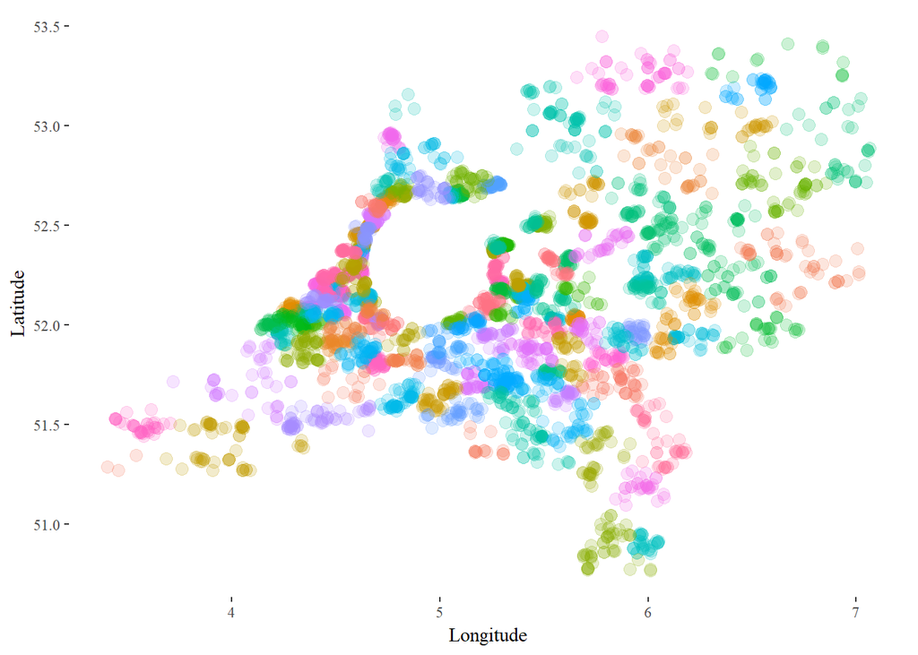

```r
clustercenters <- saved_clusters_plot %>%
  group_by(clustnum) %>%
  summarise(lat = mean(lat),
            lon = mean(lon)) %>%
  mutate(pointtype = "centers")

ggplot(data = saved_clusters_plot, aes(lon, lat))+
  geom_point(aes(col = as.factor(clustnum)), alpha = 0.2, size = 3)+
  guides(col=FALSE)+
  scale_fill_brewer(palette="Paired")+
  theme_tufte()+
  labs(x ="Longitude", y = "Latitude")+
  ggsave("clustereddata.png")
```

This plot shows the center of each cluster, which would be the optimal place for a pick-uppoint for that group.

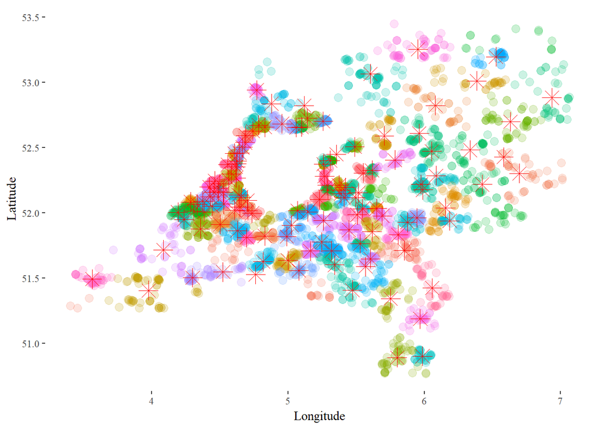

```r
ggplot(data = saved_clusters_plot, aes(lon, lat))+
  geom_point(aes(col = as.factor(clustnum)), alpha = 0.2, size = 3)+
  geom_point(data = clustercenters, shape = 8, col = "red", size = 5)+
  guides(col=FALSE)+
  scale_fill_brewer(palette="Paired")+
  theme_tufte()+
  labs(x ="Longitude", y = "Latitude")+
  ggsave("clustercenters.png")
```